# Tolerance & Carbon source SynCom strains

Thoenen et al. BX SynComs

Lisa Thoenen

2025-08-15

**set working directory to source file location**

1. Library loading, setting up misc functions
2. Metadata
3. Load raw growth data
4. Formatting Subset experiments
5. Split wells to row and column For plotting convenience, split well into row (chars) and cols (number)

filter and keep only the strains and the media conditions used here

Only look at the TSB data

Look at the MM data

for which one is there a 6th replicate? - NBCs

# Growth curves

Minimal medium with glucose or MBOA as sole carbon source. DMSO concentration is kept constant.

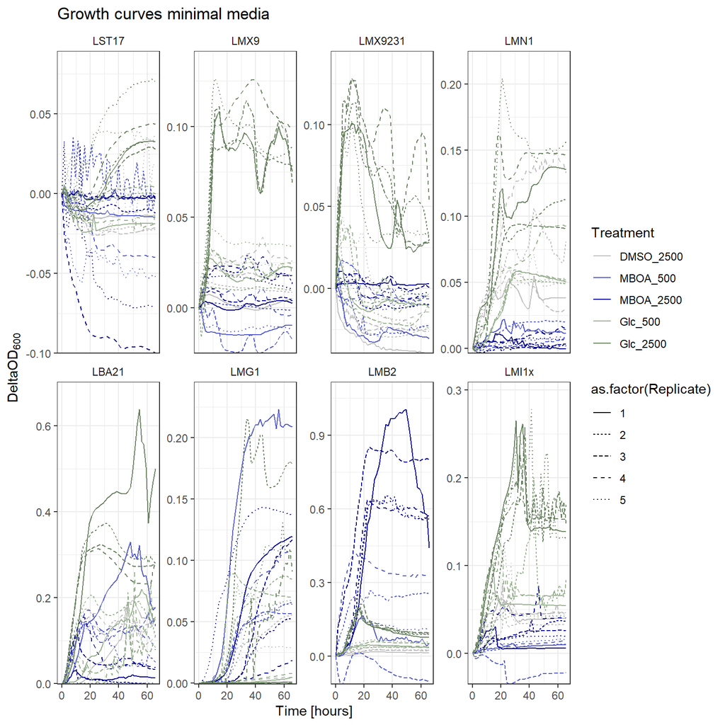

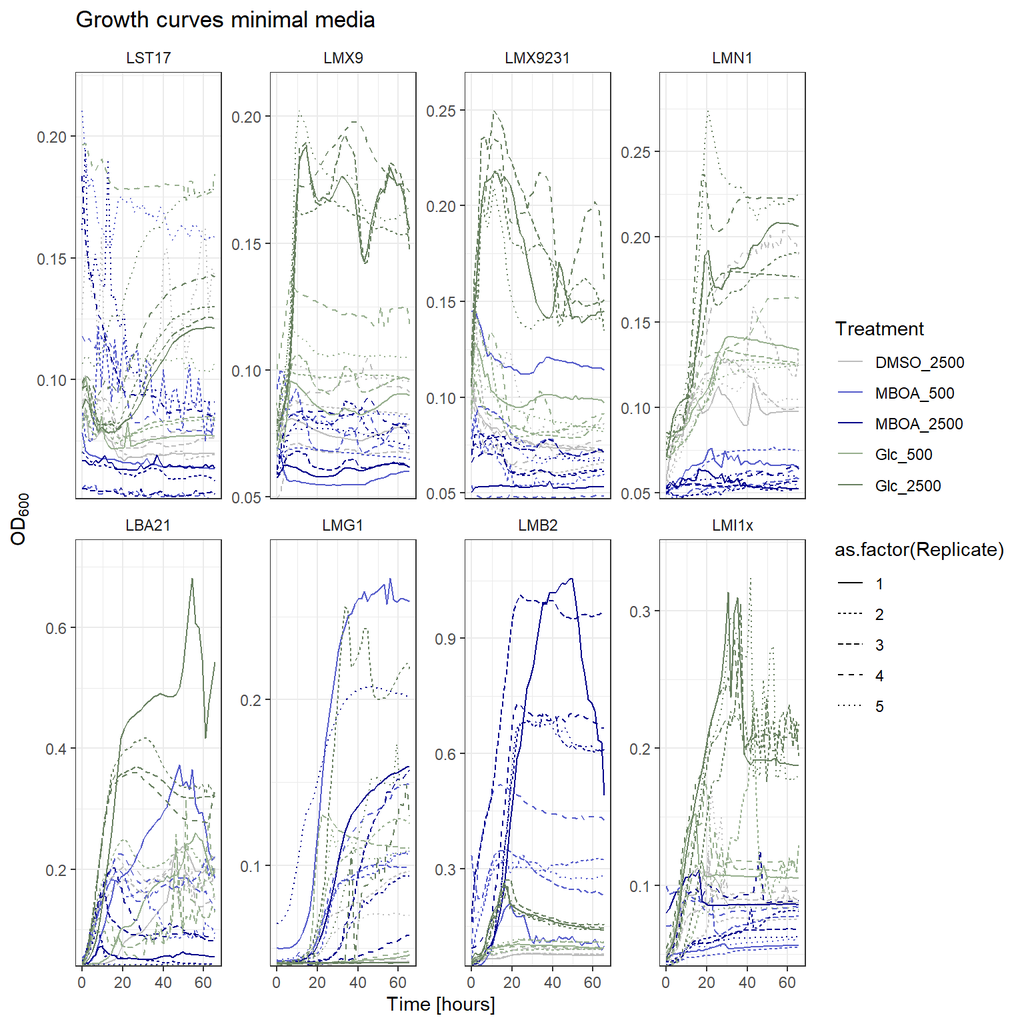

1/2 TSB supplemented with varying concentration of MBOA. DMSO concentration is kept constant.

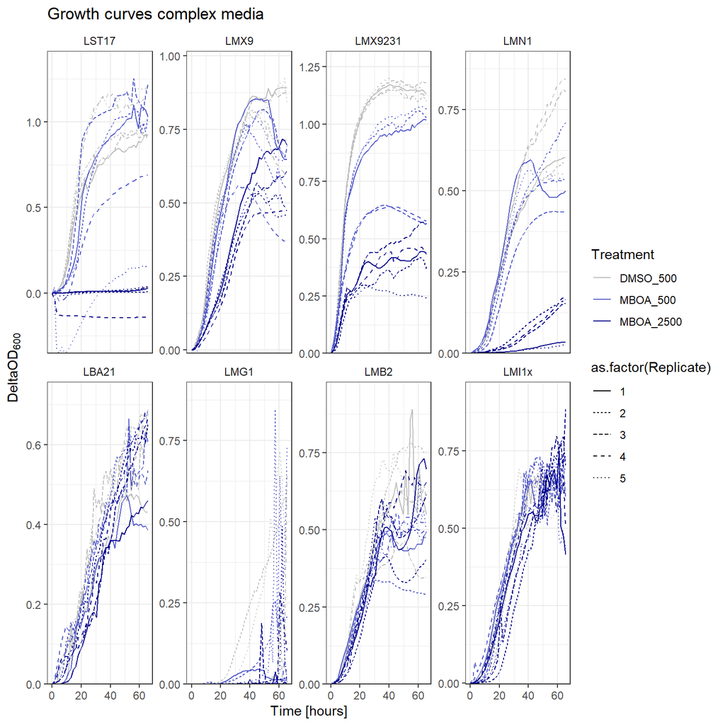

here with the OD measurements. Note that strictly speaking the mean of the NBCs should be removed.

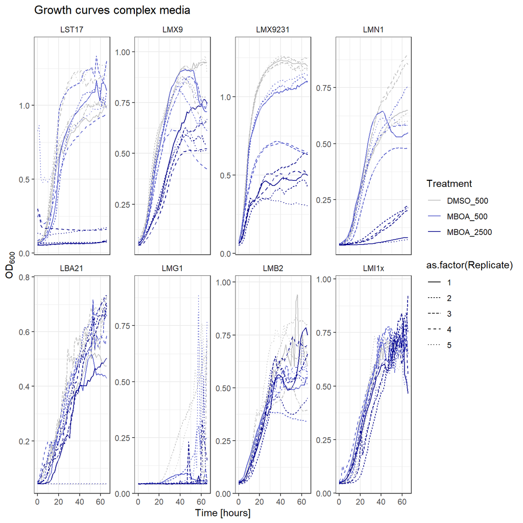

# AUC

To quantify the total bacterial growth over time, we calculate the total area under the curve. This is done with the function “auc()”. Before that, negative values for density increase were filtered out (i.e., strains or replicates that didn’t grow). For comparison between treatments, the total AUC (calculated using density increase) and AUC_raw (calculated using raw density) is normalized with the AUC of the strain grown in the control treatment (no chemicals added, just normal growth media with DMSO).

[output not shown]

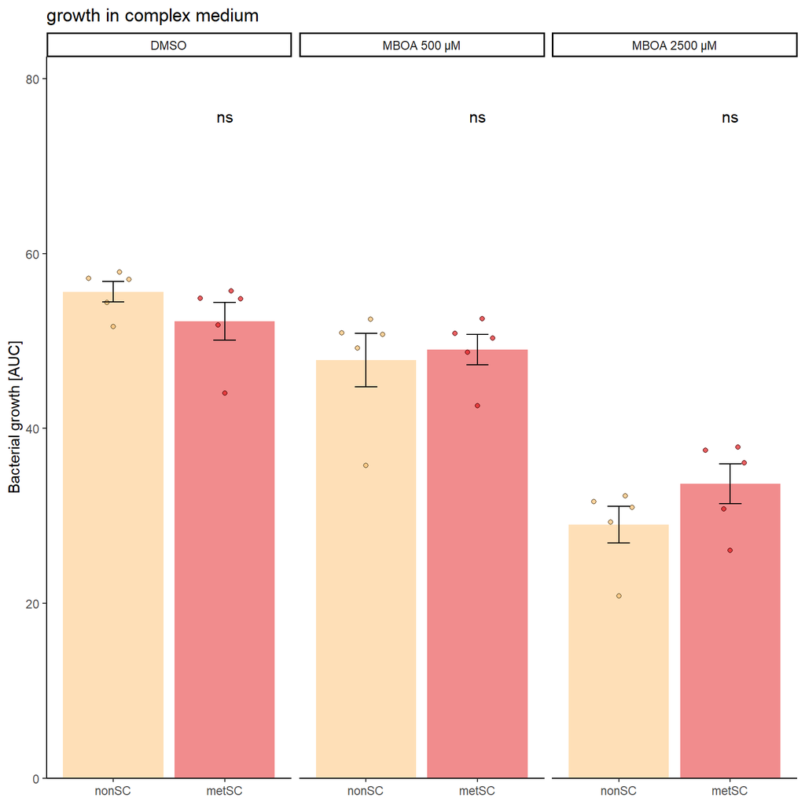

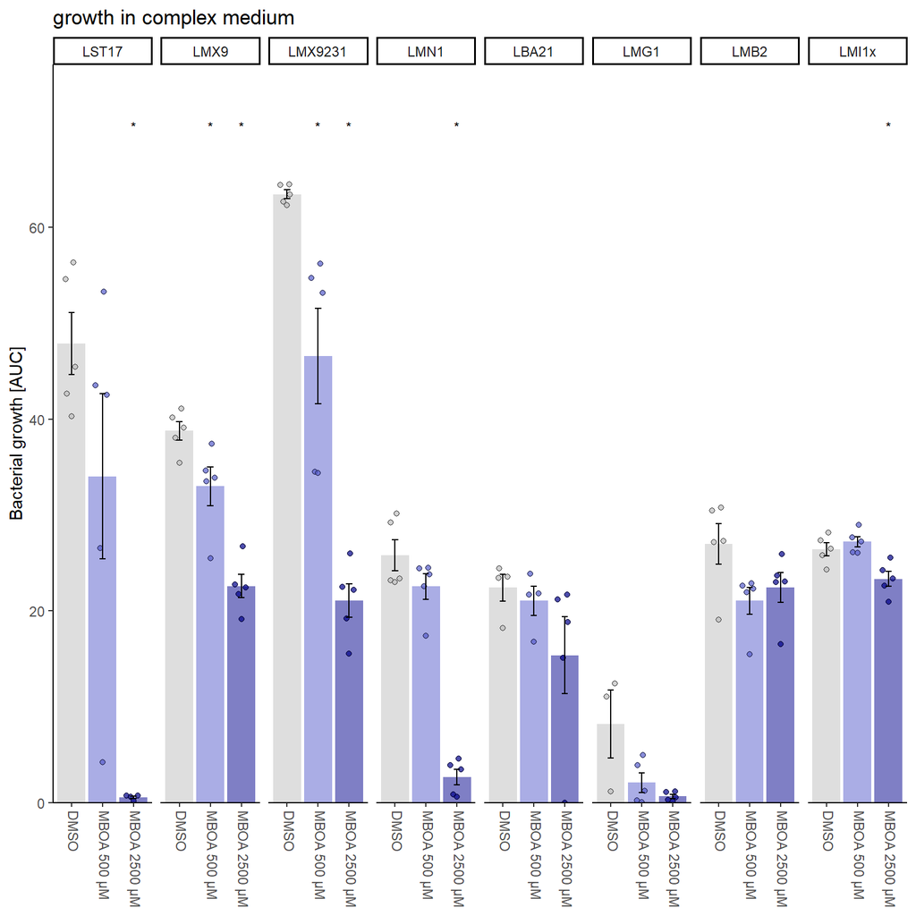

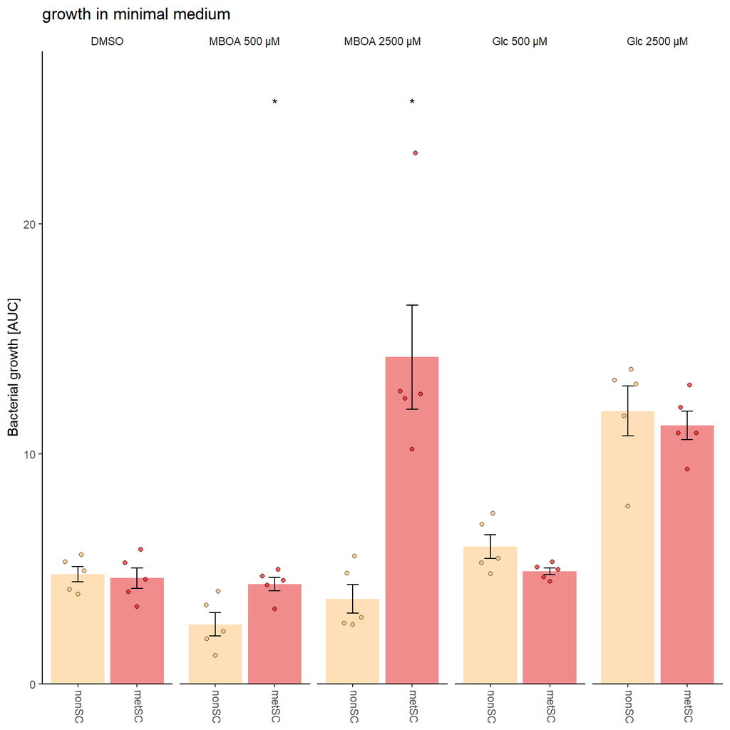

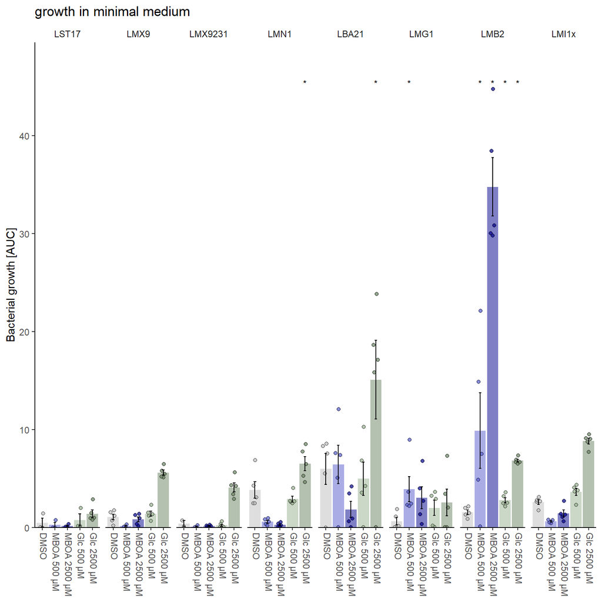

# Tolerance index

Check data

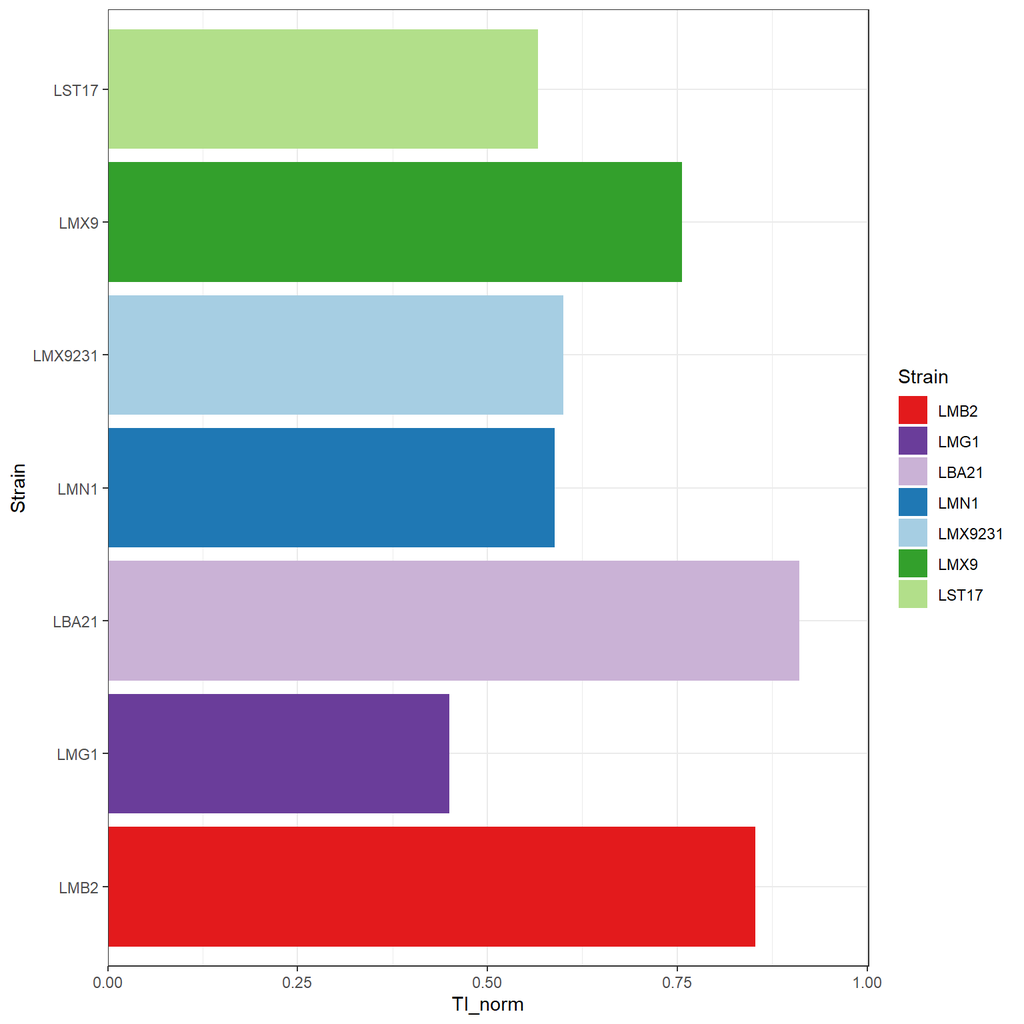

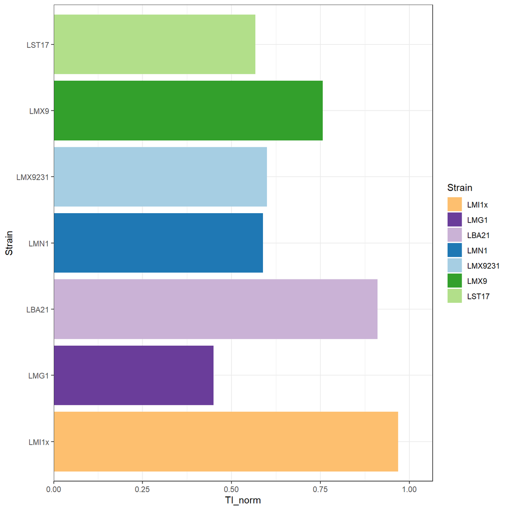